# Homework_9

Brian Hu bth997

2025-15-10

Github: https://github.com/brianbevo/Homework_9

## Question 1

### Part A

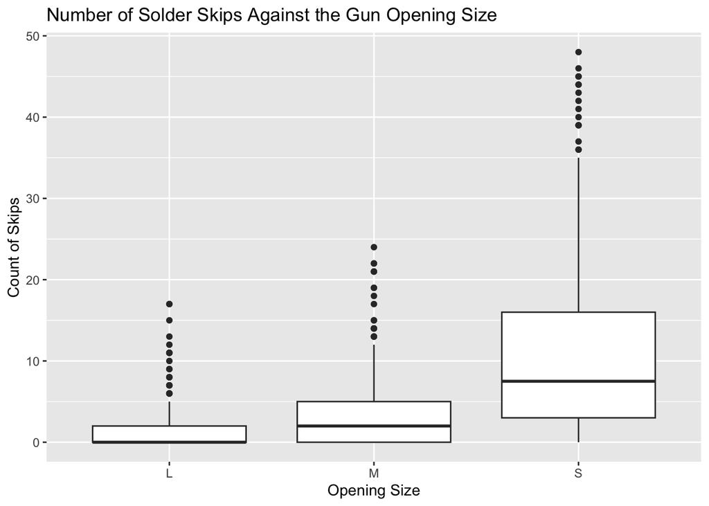

This graph of a boxplot shows the number of solder skips based off the given opening size and it can seen that large openings often have the lowest average number of skips then medium openings and finally small openings with the greatest number in average of skips.

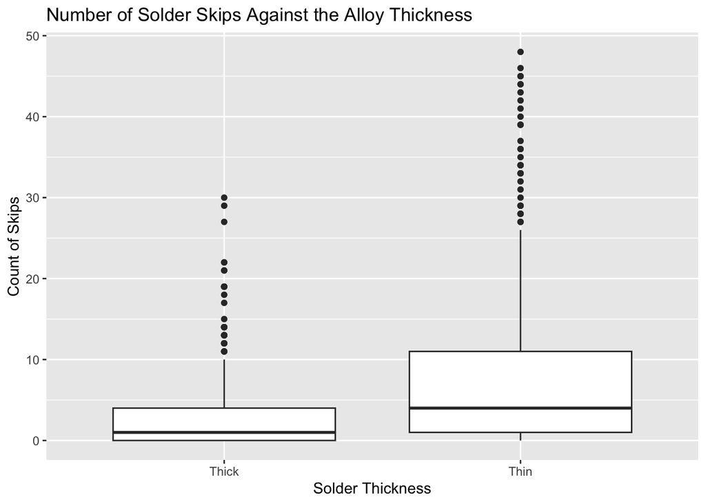

This boxplot demonstrates the number of solder skips are seen by alloy thickness, and we see that Thin thickeness alloys have a much higher median of skips than the Thick thickness alloys, along with having more and higher outliers.

### Part B

```
##                  name       lower       upper level     method    estimate
## 1           Intercept   0.2278430   0.5877875  0.95 percentile   0.3933333
## 2            OpeningM   1.7227839   3.1199651  0.95 percentile   2.4066667
## 3            OpeningS   4.1639586   6.1495318  0.95 percentile   5.1266667
## 4          SolderThin   1.7054230   2.8873684  0.95 percentile   2.2800000
## 5 OpeningM.SolderThin  -1.9635603   0.4955442  0.95 percentile  -0.7400000
## 6 OpeningS.SolderThin   7.3866609  11.9372746  0.95 percentile   9.6533333
## 7               sigma   5.8286573   6.8665385  0.95 percentile   6.3729241
## 8           r.squared   0.3794268   0.4922736  0.95 percentile   0.4339639
## 9                   F 109.3207231 173.3581426  0.95 percentile 137.0809061
```

Above is a table the shows estimates and has 95% confint applied.

### Part C

Starting with the baseline setup—a large opening and thick solder—the average number of solder skips is estimated to be 0.393.

If you switch from a large opening to a medium one while still using thick solder, you can expect the average number of skips to go up by about 2.4. That’s how much more likely skips are with a medium opening compared to the large opening baseline.

Moving from a large to a small opening again with thick solder has an even bigger impact, increasing the average number of skips by roughly 5.1. So, the smaller the opening, the more skips you’re likely to see.

Changing the solder itself from thick to thin while keeping the large opening also increases the average skips—by about 2.3. In other words, thin solder tends to cause more skips than thick solder.

Combining a medium opening with thin solder, the result is actually a bit better than you’d expect from just adding their individual effects. The average number of skips drops by 0.74 compared to what you’d get from simply adding up the separate impacts of medium opening and thin solder.

On the other hand, pairing a small opening with thin solder makes things much worse than expected. This combination leads to an average of 9.65 more skips than you’d get by adding the effects of a small opening and thin solder on their own.

### Part D

6 combinations of solder type and opening size:

Opening Size Solder Type Calculation Estimated # of Skips Large Thick 0.393 = 0.393 Large Thin 0.393 + 2.280 = 2.673 Medium Thick 0.393 + 2.407 = 2.800 Medium Thin 0.393 + 2.407 + 2.280 - 0.740 = 4.340 Small Thick 0.393 + 5.127 = 5.520 Small Thin 0.393 + 5.127 + 2.280 + 9.653 = 17.453

Based on these all given combinations, I’d recommend having the large opening size and the thick solder as we can see it has the lowest average number of skips in the process at .393.

## Question 2

### Part A

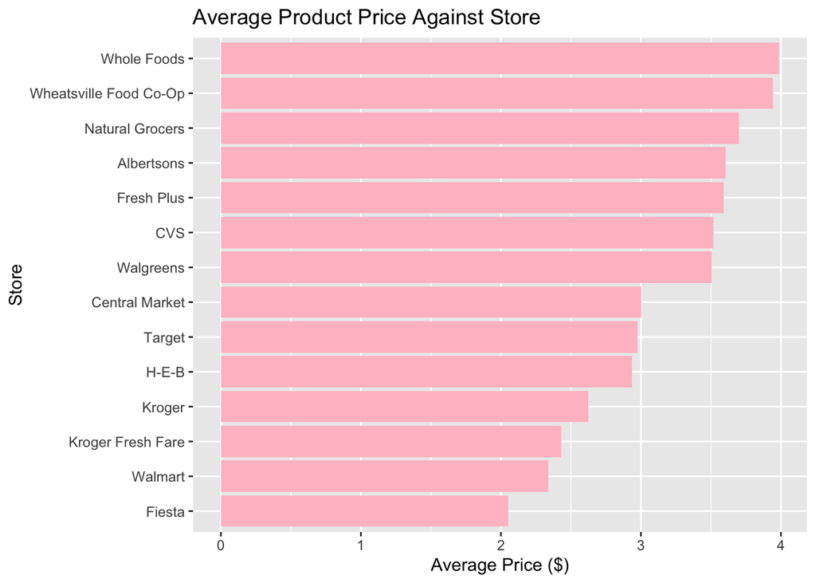

The bar graph above shows the distribution of average prices across diferrent stores with Whole Foods having the hghest average price while Fiesta having the lowest price on average.

### Part B

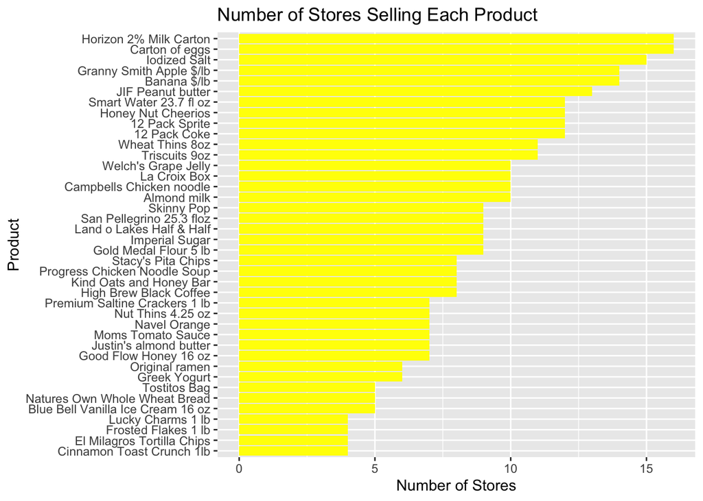

The graph above is able to show the distribution of product availability in 16 different locations of stores and the goods Horizon 2 percent Milk and eggs being rpesent in every story while the least accessible product was torilla chips and certain types of cereal brands.

### Part C

```
##                                               2.5 %        97.5 %
## (Intercept)                               5.4461802  6.4011154524
## Product12 Pack Sprite                    -0.6340950  0.5974283379
## ProductAlmond milk                       -2.8525515 -1.5573896506
## ProductBanana $/lb                       -5.4799319 -4.2894146000
## ProductBlue Bell Vanilla Ice Cream 16 oz -3.7520923 -2.1421358570
## ProductCampbells Chicken noodle          -4.1115515 -2.8163896506
## ProductCarton of eggs                    -3.5774725 -2.4241176770
## ProductCinnamon Toast Crunch 1lb         -1.8696613 -0.1241717453
## ProductEl Milagros Tortilla Chips        -2.9129671 -1.1651607441
## ProductFrosted Flakes 1 lb               -2.1246613 -0.3791717453
## ProductGold Medal Flour 5 lb             -2.8372300 -1.5046125814
## ProductGood Flow Honey 16 oz              0.2808176  1.7240341201
## ProductGranny Smith Apple $/lb           -4.3199319 -3.1294146000
## ProductGreek Yogurt                      -4.6079636 -3.0970491791
## ProductHigh Brew Black Coffee            -3.6121524 -2.2295143472
## ProductHoney Nut Cheerios                -2.3416352 -1.1094592274
## ProductHorizon 2% Milk Carton            -1.6774725 -0.5241176770
## ProductImperial Sugar                    -3.1483411 -1.8157236926
## ProductIodized Salt                      -4.4512391 -3.2812048876
## ProductJIF Peanut butter                 -3.3245622 -2.1168826179
## ProductJustin's almond butter             6.0836747  7.5268912630
## ProductKind Oats and Honey Bar           -2.5550655 -1.1701652933
## ProductLa Croix Box                      -1.7195515 -0.4243896506
## ProductLand o Lakes Half & Half          -3.9644300 -2.6289732430
## ProductLucky Charms 1 lb                 -2.3746613 -0.6291717453
## ProductMoms Tomato Sauce                  0.7236747  2.1668912630
## ProductNatures Own Whole Wheat Bread     -3.2238381 -1.6152736311
## ProductNavel Orange                      -4.6806110 -3.2373944513
## ProductNut Thins 4.25 oz                 -3.1963253 -1.7531087370
## ProductOriginal ramen                    -5.8118874 -4.3004408731
## ProductPremium Saltine Crackers 1 lb     -3.0518795 -1.6146755310
## ProductProgress Chicken Noodle Soup      -3.7593438 -2.3812397045
## ProductSan Pellegrino 25.3 floz          -4.3177633 -2.9823065764
## ProductSkinny Pop                        -2.7046528 -1.3717357209
## ProductSmart Water 23.7 fl oz            -4.3084790 -3.0761838276
## ProductStacy's Pita Chips                -2.4986751 -1.1174141159
## ProductTostitos Bag                      -2.4860923 -0.8761358570
## ProductTriscuits 9oz                     -2.8861621 -1.6263080570
## ProductWelch's Grape Jelly               -3.5819230 -2.2890645533
## ProductWheat Thins 8oz                   -2.8952530 -1.6353989661
## TypeGrocery                              -0.9154098 -0.4131031458
## TypeHigh-end Grocery                     -0.5944834 -0.0008968566
## TypeNatural                              -0.4037250  0.2192581912
## TypeSmall Format                         -0.7454724 -0.1428388392
```

Compared to major supermarkets such as Albertsons, HEB, or Kroger, convenience stores typically add between 41 and 92 cents to the price of identical items with convenience stores serving as the reference point in this model.

### Part D

```
##                              (Intercept)
##                               5.75467102
##                    Product12 Pack Sprite
##                              -0.01833333
##                       ProductAlmond milk
##                              -2.29296977
##                       ProductBanana $/lb
##                              -4.85693618
## ProductBlue Bell Vanilla Ice Cream 16 oz
##                              -3.07796542
##          ProductCampbells Chicken noodle
##                              -3.55196977
##                    ProductCarton of eggs
##                              -2.98094026
##         ProductCinnamon Toast Crunch 1lb
##                              -1.17329768
##        ProductEl Milagros Tortilla Chips
##                              -1.91049850
##               ProductFrosted Flakes 1 lb
##                              -1.42829768
##             ProductGold Medal Flour 5 lb
##                              -2.24497040
##             ProductGood Flow Honey 16 oz
##                               0.90422020
##           ProductGranny Smith Apple $/lb
##                              -3.69693618
##                      ProductGreek Yogurt
##                              -3.93157321
##            ProductHigh Brew Black Coffee
##                              -3.01257661
##                ProductHoney Nut Cheerios
##                              -1.67833193
##            ProductHorizon 2% Milk Carton
##                              -1.08094026
##                    ProductImperial Sugar
##                              -2.59735628
##                      ProductIodized Salt
##                              -3.85508884
##                 ProductJIF Peanut butter
##                              -2.63260723
```

[output cut: 51 more lines]

```
##                              -0.70331815
##                   StoreKroger Fresh Fare
##                              -0.90177969
##                     StoreNatural Grocers
##                              -0.08117985
##                              StoreTarget
##                              -0.37336967
##                           StoreWalgreens
##                               0.21548328
##                             StoreWalmart
##                              -0.99254892
##              StoreWheatsville Food Co-Op
##                               0.29029303
##                         StoreWhole Foods
##                               0.36415850
```

According to the regression analysis, Walmart and Kroger Fresh Fare offer the lowest prices for identical products among the stores compared. On the other end, Wheatsville Food Co-Op and Whole Foods are the most expensive options for the same items.

### Part E

When it comes to Central Market and HEB, Central Market does charge a little more—about 7 cents extra per product on average. But if you zoom out and look at all the stores in the study, the price difference between the cheapest and most expensive stores for the same product can be as much as $1.36. So, in the grand scheme of things, that 7-cent difference between Central Market and HEB isn’t all that significant.

### Part F

```
## # Standardization method: refit
##
## Parameter                                   | Std. Coef. |         95% CI
## -------------------------------------------------------------------------
## (Intercept)                                 |       1.08 | [ 0.86,  1.31]
## Product [12 Pack Sprite]                    |  -9.03e-03 | [-0.33,  0.31]
## Product [Almond milk]                       |      -1.04 | [-1.37, -0.71]
## Product [Banana $/lb]                       |      -2.42 | [-2.72, -2.11]
## Product [Blue Bell Vanilla Ice Cream 16 oz] |      -1.43 | [-1.85, -1.02]
## Product [Campbells Chicken noodle]          |      -1.66 | [-1.99, -1.33]
## Product [Carton of eggs]                    |      -1.46 | [-1.76, -1.17]
## Product [Cinnamon Toast Crunch 1lb]         |      -0.59 | [-1.04, -0.14]
## Product [El Milagros Tortilla Chips]        |      -0.98 | [-1.43, -0.53]
## Product [Frosted Flakes 1 lb]               |      -0.71 | [-1.16, -0.26]
## Product [Gold Medal Flour 5 lb]             |      -1.03 | [-1.38, -0.69]
## Product [Good Flow Honey 16 oz]             |       0.52 | [ 0.15,  0.89]
## Product [Granny Smith Apple $/lb]           |      -1.85 | [-2.15, -1.54]
## Product [Greek Yogurt]                      |      -1.93 | [-2.32, -1.54]
## Product [High Brew Black Coffee]            |      -1.39 | [-1.75, -1.03]
## Product [Honey Nut Cheerios]                |      -0.83 | [-1.15, -0.52]
## Product [Horizon 2% Milk Carton]            |      -0.53 | [-0.83, -0.23]
## Product [Imperial Sugar]                    |      -1.19 | [-1.53, -0.85]
## Product [Iodized Salt]                      |      -1.89 | [-2.19, -1.59]
## Product [JIF Peanut butter]                 |      -1.35 | [-1.67, -1.04]
## Product [Justin's almond butter]            |       3.38 | [ 3.01,  3.75]
## Product [Kind Oats and Honey Bar]           |      -0.83 | [-1.19, -0.47]
## Product [La Croix Box]                      |      -0.48 | [-0.82, -0.15]
## Product [Land o Lakes Half & Half]          |      -1.56 | [-1.91, -1.22]
## Product [Lucky Charms 1 lb]                 |      -0.84 | [-1.29, -0.39]
## Product [Moms Tomato Sauce]                 |       0.74 | [ 0.37,  1.11]
## Product [Natures Own Whole Wheat Bread]     |      -1.22 | [-1.63, -0.80]
## Product [Navel Orange]                      |      -1.92 | [-2.29, -1.55]
## Product [Nut Thins 4.25 oz]                 |      -1.19 | [-1.56, -0.82]
## Product [Original ramen]                    |      -2.45 | [-2.84, -2.06]
## Product [Premium Saltine Crackers 1 lb]     |      -1.11 | [-1.48, -0.74]
## Product [Progress Chicken Noodle Soup]      |      -1.49 | [-1.85, -1.13]
## Product [San Pellegrino 25.3 floz]          |      -1.74 | [-2.08, -1.39]
## Product [Skinny Pop]                        |      -0.96 | [-1.31, -0.62]
## Product [Smart Water 23.7 fl oz]            |      -1.84 | [-2.16, -1.52]
## Product [Stacy's Pita Chips]                |      -0.83 | [-1.18, -0.47]
## Product [Tostitos Bag]                      |      -0.81 | [-1.22, -0.39]
## Product [Triscuits 9oz]                     |      -1.13 | [-1.45, -0.80]
## Product [Welch's Grape Jelly]               |      -1.48 | [-1.82, -1.15]
## Product [Wheat Thins 8oz]                   |      -1.13 | [-1.46, -0.81]
## Income10K                                   |      -0.03 | [-0.07,  0.01]
```

## Question 3

### Part D

False. When income is added to the model, the effect of minority percentage on FAIR policies does get a bit smaller (from 0.014 to 0.01), but it’s still statistically significant. The confidence interval doesn’t include zero, and the p-value is still very low (0.002). So, even after accounting for income, minority percentage still matters. In other words, income explains some, but not all, of the relationship.

### Part E

True. Even when you account for fire risk, income, and housing age all at once, minority percentage still has a positive and significant effect on the number of FAIR policies (the estimate is 0.008, with a confidence interval from 0.003 to 0.014 and a p-value of 0.006). This means that, regardless of those other factors, areas with more minorities tend to have more FAIR policies.